# MLIT grants to prefectures, FY2022-2026

## Introduction

- MLIT: Ministry of Land, Infrastructure, Transport and Tourism (国土交通省), the national ministry in charge of roads, rivers, ports, urban planning and housing.
- This page tracks MLIT’s two block grants to local governments, FY2022-2026, and where the FY2026 cuts fell:
  - (a) 社会資本整備総合交付金
  - (b) 防災・安全交付金
- Prefecture level: allocations of (a), (b) and (c) = (a) + (b), parsed from the MLIT press-release PDFs; year-on-year change as a histogram (Figure 1) and a map (Figure 2).
- Municipal level, road projects only: national share by implementing municipality, parsed from the Road Bureau PDFs (47 prefectures x 5 years); change histograms (Figure 3, Figure 4), a national map (Figure 5) and a Kanto map (Figure 6).
- News check: Nakagawa and Nasukarasuyama, the two towns in the news report, and where their FY2026 cuts rank (Table 1); Kanto municipalities with cuts at least as large (Table 2).
- PDFs and boundary files are downloaded only if missing from `data/`; the road-PDF parsing chunk is a record and is not run (`eval: false`).

## The two grants

MLIT (国土交通省) initial allocations of its two block grants:

1. 社会資本整備総合交付金 (Comprehensive Grant for Social Capital Development): block grant for growth-oriented infrastructure planned by local governments, e.g. roads, urban redevelopment, sewerage, housing, ports
2. 防災・安全交付金 (Disaster Prevention and Safety Grant): block grant for disaster prevention and mitigation, ageing-infrastructure renewal and safety, e.g. school-route safety, bridge repair, flood control
3. total of a + b (社会資本総合整備事業 計)
- Both are paid to prefectures and municipalities per multi-year plan (整備計画); the local government picks projects within the plan
- Prefecture section: all expenditure items; municipal section: road projects only (道路分)

Notes on the data:

- Source: “国土交通省関係予算の配分について” press releases, attachment “社会資本整備総合交付金”, table Ⅲ 都道府県別配分額
- Unit: project cost (事業費), million yen; MLIT estimates it from the national grant
- Level: prefecture; each figure includes the prefecture’s municipalities (no municipal table is published)
- Initial (当初) allocations only; supplementary budgets (補正) excluded

**Code (Setup: packages, download PDFs and boundaries)**

```r
options(repos = c(CRAN = "https://cran.ism.ac.jp/"))  # Japan mirror (ISM, Tokyo)
pkgs <- c("data.table", "pdftools", "sf", "qs2", "ggplot2", "ggrepel", "tinytable")
new <- pkgs[!vapply(pkgs, requireNamespace, logical(1), quietly = TRUE)]
if (length(new) > 0) install.packages(new)
library(data.table)
library(ggplot2)
library(tinytable)
# Tables: striped rows, faint blue header, small font, text columns left / numbers right
ttj <- function(x, txt, num) {
  y <- tt(x, theme = "striped")
  y <- style_tt(y, i = 0, background = "#e7f0fa")
  y <- style_tt(y, fontsize = 0.85)
  y <- style_tt(y, j = txt, align = "l")
  style_tt(y, j = num, align = "r")
}
dir.create("data", showWarnings = FALSE)

# Download once into data/: one PDF per fiscal year + GADM 4.1 prefecture boundaries
mlit <- "https://www.mlit.go.jp/report/press/content/"
src <- c(R4_shakai.pdf = paste0(mlit, "001472659.pdf"),   # FY2022
         R5_shakai.pdf = paste0(mlit, "001598653.pdf"),   # FY2023
         R6_shakai.pdf = paste0(mlit, "001735799.pdf"),   # FY2024
         R7_shakai.pdf = paste0(mlit, "001881396.pdf"),   # FY2025
         R8_shakai.pdf = paste0(mlit, "001994790.pdf"),   # FY2026
         gadm41_JPN_1.json.zip =
           "https://geodata.ucdavis.edu/gadm/gadm4.1/json/gadm41_JPN_1.json.zip")
for (f in names(src)) if (!file.exists(file.path("data", f)))
  download.file(src[f], file.path("data", f), mode = "wb")

# Prefecture short names in JIS code order 1-47 (as printed in MLIT tables)
jis <- c("北海道", "青森", "岩手", "宮城", "秋田", "山形", "福島", "茨城", "栃木", "群馬",
         "埼玉", "千葉", "東京", "神奈川", "新潟", "富山", "石川", "福井", "山梨", "長野",
         "岐阜", "静岡", "愛知", "三重", "滋賀", "京都", "大阪", "兵庫", "奈良", "和歌山",
         "鳥取", "島根", "岡山", "広島", "山口", "徳島", "香川", "愛媛", "高知", "福岡",
         "佐賀", "長崎", "熊本", "大分", "宮崎", "鹿児島", "沖縄")
glab <- c(a = "(a) Social Capital Development", b = "(b) Disaster Prevention & Safety",
           c = "(c) Total")
gjp <- c(a = "(a) 社会資本整備総合交付金", b = "(b) 防災・安全交付金", c = "(c) 合計")
```

**Code (Read prefecture tables, compute % change)**

```r
# Prefecture table: rows "name  a  b  total" on the page titled 都道府県別配分額
read_pref <- function(f) {
  pg <- pdftools::pdf_text(f)
  pg <- pg[grepl("都道府県別配分額", pg) & grepl("北海道", pg)]
  ln <- unlist(strsplit(pg, "\n"))
  re <- "^\\s*([^0-9,\\s][^0-9,]*?)\\s+([0-9,]+)\\s+([0-9,]+)\\s+([0-9,]+)\\s*$"
  ln <- ln[grepl(re, ln, perl = TRUE)]
  x <- as.data.table(do.call(rbind, regmatches(ln, regexec(re, ln, perl = TRUE)))[, -1])
  setnames(x, c("pref", "a", "b", "c"))
  x[, pref := gsub("\\s", "", pref)]
  x[, c("a", "b", "c") := lapply(.SD, function(v) as.numeric(gsub(",", "", v))),
    .SDcols = c("a", "b", "c")]
  #### CLAUDE bug1: 2026-10-14 MLIT lists prefectures in regional-bureau order, not JIS order
  #### (山梨, 長野 after 神奈川; 福井 after 三重), so seq_len(.N) mis-coded 10 prefectures
  # x[pref != "合計"][, code := seq_len(.N)][]
  x[pref != "合計"][, code := match(pref, jis)][]
}
fy <- c(R4 = 2022L, R5 = 2023L, R6 = 2024L, R7 = 2025L, R8 = 2026L)
gr <- rbindlist(lapply(names(fy), function(r)
  read_pref(file.path("data", paste0(r, "_shakai.pdf")))[, fy := fy[r]]))
stopifnot(gr[, .N, by = fy][, all(N == 47)], !anyNA(gr$code),
          gr[, uniqueN(code), by = fy][, all(V1 == 47)])

# Long panel and year-on-year change (%) within prefecture and grant
gl <- melt(gr, id.vars = c("fy", "code", "pref"), variable.name = "grant",
           value.name = "mn_yen", variable.factor = FALSE)
setorder(gl, grant, code, fy)
gl[, chg := 100 * (mn_yen / shift(mn_yen) - 1), by = .(grant, code)]
gl[, grant_lab := factor(glab[grant], levels = glab)]
qs2::qs_save(gl, "data/mlit_grants_pref.qs2")
fwrite(gl[, .(fy, code, pref, grant, mn_yen, chg)], "data/mlit_grants_pref.csv", bom = TRUE)

# National totals by year (million yen) and mean/std of prefecture changes
nt <- dcast(gl[, .(total = sum(mn_yen)), by = .(fy, grant)], fy ~ grant, value.var = "total")
nt <- nt[, .(`年度` = paste0("FY", fy), a = format(a, big.mark = ","),
             b = format(b, big.mark = ","), c = format(c, big.mark = ","))]
setnames(nt, c("a", "b", "c"), gjp)
ttj(nt, 1, 2:4)
```

| 年度 | (a) 社会資本整備総合交付金 | (b) 防災・安全交付金 | (c) 合計 |
| --- | --- | --- | --- |
| FY2022 | 1,189,230 | 1,553,129 | 2,742,355 |
| FY2023 | 1,104,764 | 1,576,444 | 2,681,210 |
| FY2024 | 1,019,487 | 1,663,720 | 2,683,201 |
| FY2025 | 981,738 | 1,608,950 | 2,590,690 |
| FY2026 | 921,500 | 1,615,213 | 2,536,708 |

**Code (Read prefecture tables, compute % change)**

```r
ps <- gl[!is.na(chg), .(n = .N, `平均%` = sprintf("%.1f", mean(chg)), `std` = sprintf("%.1f", sd(chg)),
                        `最小%` = sprintf("%.1f", min(chg)), `最大%` = sprintf("%.1f", max(chg))),
         keyby = grant]
ps <- ps[, c(list(`交付金` = gjp[grant]), .SD), .SDcols = !"grant"]
ttj(ps, 1, 2:6)
```

| 交付金 | n | 平均% | std | 最小% | 最大% |
| --- | --- | --- | --- | --- | --- |
| (a) 社会資本整備総合交付金 | 188 | -4.8 | 13.7 | -38.3 | 44.6 |
| (b) 防災・安全交付金 | 188 | 2.6 | 12.0 | -28.5 | 77.1 |
| (c) 合計 | 188 | -0.9 | 7.8 | -23.3 | 25.7 |

**Code (Fig: histogram of prefecture changes)**

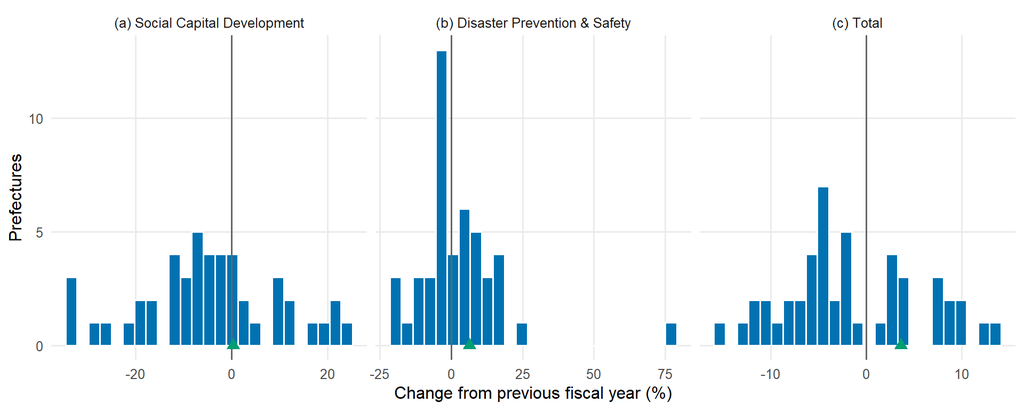

Figure 1: Year-on-year change in allocation (%, FY2025-26), 47 prefectures. Green triangle: Tochigi prefecture.  
Source: MLIT press releases, FY2025-FY2026 (国土交通省関係予算の配分について, 表Ⅲ 都道府県別配分額; 事業費)

```r
tochigi <- gl[code == 9 & fy == max(fy)]                 # JIS code 9 = Tochigi
#### CLAUDE chg: 2026-10-19 user asked FY2025-26 changes only (was all 4 years pooled)
# p_hist <- ggplot(gl[!is.na(chg)], aes(chg)) +
p_hist <- ggplot(gl[fy == max(fy) & !is.na(chg)], aes(chg)) +
  geom_histogram(bins = 25, fill = "#0072B2", colour = "white") +
  geom_vline(xintercept = 0, colour = "grey40") +
  geom_point(data = tochigi, aes(x = chg, y = 0), colour = "#009E73", shape = 17, size = 3) +
  facet_wrap(~grant_lab, scales = "free_x") +
#### CLAUDE chg:
#   labs(x = "Change from previous fiscal year (%)", y = "Prefecture-years") +
  labs(x = "Change from previous fiscal year (%)", y = "Prefectures") +
  theme_minimal(base_size = 12) +
  theme(panel.grid.minor = element_blank())
ggsave("data/mlit_hist_change.png", p_hist, width = 10, height = 4, dpi = 200, bg = "white")
p_hist
```

**Code (Fig: prefecture map, FY2025→26)**

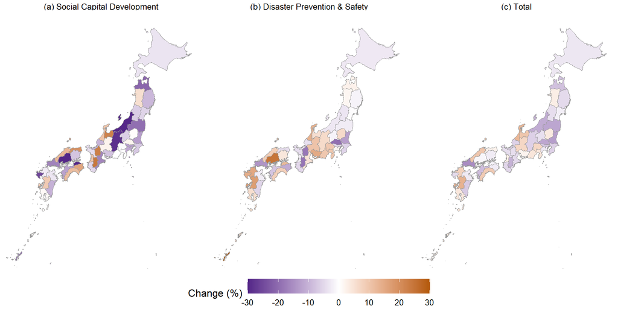

Figure 2: Change in allocation (%, FY2025-26). Purple = decrease, orange = increase; colours capped at ±30%.  
Source: MLIT press releases, FY2025-FY2026 (国土交通省関係予算の配分について, 表Ⅲ 都道府県別配分額; 事業費). Boundaries: GADM 4.1

```r
unzip("data/gadm41_JPN_1.json.zip", exdir = tempdir())
jp <- sf::st_read(file.path(tempdir(), "gadm41_JPN_1.json"), quiet = TRUE)
jp$code <- as.integer(sub("JP-", "", jp$ISO_1))           # ISO 3166-2 = JIS code
last <- gl[fy == max(fy)]
mp <- merge(jp[, "code"], last[, .(code, grant_lab, chg)], by = "code")
# Purple-orange diverging scale (ColorBrewer PuOr, colour-blind safe): purple = cut,
# orange = increase, white = no change.
# Capped at +/-30% so outliers (Okinawa (b) +77%; Niigata, Hiroshima, Kagawa (a)
# about -33%) do not wash out the rest
lim <- 30
p_map <- ggplot(mp) +
  geom_sf(aes(fill = chg), colour = "grey60", linewidth = 0.1) +
  facet_wrap(~grant_lab) +
  scale_fill_gradient2(low = "#542788", mid = "white", high = "#B35806",
                       midpoint = 0, limits = c(-lim, lim), oob = scales::squish,
                       name = "Change (%)") +
  coord_sf(xlim = c(127, 146), ylim = c(26, 46)) +
  theme_void(base_size = 12) +
  theme(legend.position = "bottom", legend.key.width = unit(1.5, "cm"))
ggsave("data/mlit_map_change_fy2026.png", p_map, width = 10, height = 5, dpi = 200, bg = "white")
p_map
```

## Municipal level: road projects (道路分)

What the news reported, checked against MLIT data:

- News: agriculture minister Kazuo Yana (簗和生) said FY2026 road budgets of Nasukarasuyama city (那須烏山市) and Nakagawa town (那珂川町), Tochigi, were “cut sharply” after their mayors backed his rival in the February 2026 election
  - [Yomiuri, 11 Oct 2026](https://news.yahoo.co.jp/articles/bf45e1d7f5fc5b6421157b18b58ba7ac83f0811a): Nakagawa, (b) 防災・安全交付金, requested 72.08m yen, allocated 22.62m yen, about −54%; Nasukarasuyama, (a)+(b), about −30% (city’s own figure)
  - [Tokyo Shimbun](https://www.tokyo-np.co.jp/article/519997): Nasukarasuyama about −63%, Nakagawa about −54%
  - [Yomiuri, MLIT explanation](https://news.yahoo.co.jp/articles/57ed758dfb5779aecc249b8faa34553b70829fc4): Nasukarasuyama, 8 city-led projects, 105m yen (−26.2%); Nakagawa, 2 town-led projects, 23m yen (−54.1%)
  - [Shimotsuke Shimbun](https://www.shimotsuke.co.jp/articles/-/1435689): MLIT investigation published 6 Oct 2026, no pressure found
- Data: MLIT Road Bureau, “社会資本整備総合交付金の配分（道路分）”, one PDF per prefecture and year (`https://www.mlit.go.jp/road/ir/ir-yosan/r8yhai/pdf/sha/1309k.pdf` = Tochigi FY2026)
  - 別紙 (annex) lists each road project with its implementing body (事業実施主体) and expected national share (想定国費, 1,000 yen)
  - Coverage: road part of (a) and (b) only; projects in plans without an annex are not itemised; Okinawa has no (b) annex
- Result (Table 1): the news figures are national shares of road projects implemented by the municipality
  - Nakagawa −54.1% is (b) only (it has no (a) projects); 22,624 thousand yen = the 22.62m yen in Yomiuri
  - Nasukarasuyama −62.9% is (a) only; (b) is -18.5%, (a)+(b) is -39.7%
    - Part of Nasukarasuyama (a)’s fall is a reclassification: 谷浅見平野線 moved from (a) in FY2025 to (b) in FY2026
    - Adding its own town-centre plan, which has no annex (5,050 → 22,220), gives 104,728 thousand yen over 8 projects, −26.2%: the MLIT figure reported by Yomiuri

**Code (Build municipal road panel from Road Bureau PDFs (not run))**

```r
# Not run at render (kept as a record): builds data/mlit_road_muni.qs2, read in the next chunk
# Download once: 47 prefectures x FY2022-2026 road-allocation PDFs (Road Bureau)
dir.create("data/road", showWarnings = FALSE)
for (r in 4:8) for (p in 1301:1347) {
  f <- sprintf("data/road/r%d_%dk.pdf", r, p)
  if (!file.exists(f))
    download.file(sprintf("https://www.mlit.go.jp/road/ir/ir-yosan/r%dyhai/pdf/sha/%dk.pdf", r, p),
                  f, mode = "wb")
}
# Parse annex rows: "... implementing-body amount"; the annex title sets the grant
parse_road <- function(f) {
  out <- list(); g <- NA_character_
  for (p in pdftools::pdf_text(f)) {
    ln <- strsplit(p, "\n")[[1]]
    if (any(grepl("の配分（道路分）", ln))) { g <- NA; next }   # plan-level summary pages
    for (l in ln) {
      if (grepl("年度.*防災・安全交付金", l)) g <- "b"
      if (grepl("年度.*社会資本整備総合交付金(（道路分）)?\\s*$", l)) g <- "a"
      m <- regmatches(l, regexec("\\s(\\S+[都道府県市町村区])\\s+([0-9,]+)\\s*$", l))[[1]]
      if (length(m) == 3 && !is.na(g))
        out[[length(out) + 1]] <- list(grant = g, entity = m[2],
                                       kyen = as.numeric(gsub(",", "", m[3])))
    }
  }
  rbindlist(out)
}
# File numbers 1301-1347 follow MLIT's regional-bureau order, not JIS order:
# take the prefecture from the cover page ("栃 木 県") and look up its JIS code
cover_code <- function(f) {
  nm <- gsub("\\s", "", strsplit(pdftools::pdf_text(f)[1], "\n")[[1]])
  nm <- sub("[都府県]$", "", nm[nzchar(nm)][1])
  match(nm, jis)
}
fs <- list.files("data/road", pattern = "^r[4-8]_13[0-9]{2}k\\.pdf$")
rd <- rbindlist(lapply(fs, function(f) {
  ff <- file.path("data/road", f)
  parse_road(ff)[, `:=`(fy = 2018L + as.integer(substr(f, 2, 2)), code = cover_code(ff))]
}))
stopifnot(!anyNA(rd$code), rd[, uniqueN(code), by = fy][, all(V1 == 47)])

# Municipality x grant x year totals (prefectures as implementers dropped); c = a + b
mu <- rd[!grepl("[都道府県]$", entity), .(kyen = sum(kyen)), by = .(code, entity, fy, grant)]
mu <- rbind(mu, mu[, .(grant = "c", kyen = sum(kyen)), by = .(code, entity, fy)])
grid <- unique(mu[, .(code, entity, grant)])[, .(fy = 2022:2026), by = .(code, entity, grant)]
mu <- mu[grid, on = .(code, entity, grant, fy)]
mu[is.na(kyen), kyen := 0]
setorder(mu, code, entity, grant, fy)
mu[, prev := shift(kyen), by = .(code, entity, grant)]
mu[, chg := fifelse(kyen > 0 & prev > 0, 100 * (kyen / prev - 1), NA_real_)]
mu[, grant_lab := factor(glab[grant], levels = glab)]
qs2::qs_save(mu, "data/mlit_road_muni.qs2")
fwrite(mu[fy > 2022, .(fy, code, entity, grant, kyen, prev, chg)], "data/mlit_road_muni.csv", bom = TRUE)
```

**Code (Load municipal road panel, count coverage)**

```r
mu <- qs2::qs_read("data/mlit_road_muni.qs2")          # made by the road-data chunk above
# Changes above +300%, omitted from the municipal histograms; counts go into their captions
omit300 <- function(d) {
  n <- table(d[chg > 300, grant_lab])                    # factor: zero counts kept, order a, b, c
  paste0(c("(a) ", "(b) ", "(a)+(b) "), as.integer(n), collapse = ", ")
}

# Coverage: municipality-grant pairs per change year (both years > 0 / entry / exit)
mu[fy > 2022, .(both = sum(!is.na(chg)), entry = sum(prev == 0 & kyen > 0),
                exit = sum(prev > 0 & kyen == 0)), by = grant_lab]
```

```
                          grant_lab  both entry  exit
                             <fctr> <int> <int> <int>
1: (b) Disaster Prevention & Safety  3501   458   525
2:                        (c) Total  4174   408   550
3:   (a) Social Capital Development  1424   380   548
```

**Code (Table: Nasukarasuyama and Nakagawa vs all municipalities)**

```r
two <- mu[code == 9 & entity %in% c("那須烏山市", "那珂川町") & fy == 2026 & kyen > 0]
pool <- mu[!is.na(chg)]
two[, pctile := 100 * pool[two, on = "grant", mean(x.chg <= i.chg), by = .EACHI]$V1]
tw <- two[, .(`自治体` = entity, `交付金` = gjp[grant],
              FY2025 = format(prev, big.mark = ","), FY2026 = format(kyen, big.mark = ","),
              `変化%` = sprintf("%.1f", chg), `百分位` = sprintf("%.1f", pctile))]
ttj(tw, 1:2, 3:6)
```

Table 1: The two municipalities: road-project national share (1,000 yen), FY2025 and FY2026, and percentile of the FY2026 change among all municipal changes FY2022-23 to FY2025-26.

| 自治体 | 交付金 | FY2025 | FY2026 | 変化% | 百分位 |
| --- | --- | --- | --- | --- | --- |
| 那珂川町 | (b) 防災・安全交付金 | 49,342 | 22,624 | -54.1 | 11.9 |
| 那珂川町 | (c) 合計 | 49,342 | 22,624 | -54.1 | 11.8 |
| 那須烏山市 | (a) 社会資本整備総合交付金 | 65,351 | 24,267 | -62.9 | 9.6 |
| 那須烏山市 | (b) 防災・安全交付金 | 71,437 | 58,241 | -18.5 | 34.9 |
| 那須烏山市 | (c) 合計 | 136,788 | 82,508 | -39.7 | 19.3 |

- The two municipalities are not outliers: each FY2026 change sits between the 9.6th and 34.9th percentile of all municipal changes FY2022-23 to FY2025-26.
  - The largest cut, 那須烏山市 (a) −62.9%, is matched or exceeded by 9.6% of municipality-year changes in grant (a); the pooled 10th percentile is −62.4%.
  - 那珂川町’s −54.1% is at the 11.9th (b) and 11.8th (c) percentile.
- So the data show no distinctive anomaly in these two towns’ grant changes.

**Code (Fig: histogram of municipal road changes, FY2025-26)**

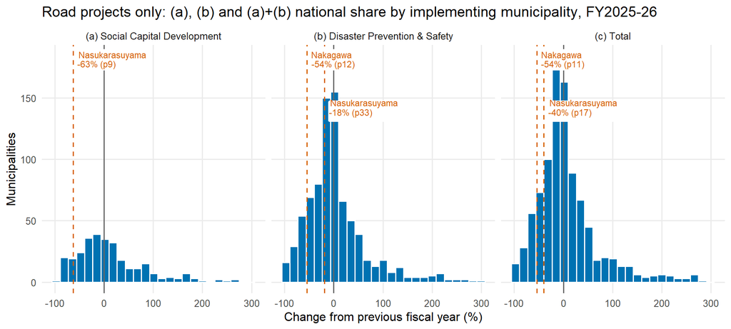

Figure 3: Year-on-year change in road-project national share (%, FY2025-26), by implementing municipality; changes above +300% omitted ((a) 16, (b) 38, (a)+(b) 47 municipalities). Dashed orange: Nasukarasuyama, Nakagawa, with their percentile among FY2025-26 changes.  
Source: MLIT Road Bureau, FY2025-FY2026 (社会資本整備総合交付金の配分（道路分）, 別紙; 想定国費)

```r
pool26 <- mu[fy == 2026 & !is.na(chg)]
two[, pctile26 := 100 * pool26[two, on = "grant", mean(x.chg <= i.chg), by = .EACHI]$V1]
lab26 <- two[, .(grant_lab, chg, lab = sprintf("%s\n%.0f%% (p%.0f)",
                 c(那須烏山市 = "Nasukarasuyama", 那珂川町 = "Nakagawa")[entity], chg, pctile26))]
lab26[, vj := 1.2 + 2.4 * (seq_len(.N) - 1), by = grant_lab]   # stack labels within a panel
p_hm26 <- ggplot(pool26[chg <= 300], aes(chg)) +
  labs(title = "Road projects only: (a), (b) and (a)+(b) national share by implementing municipality, FY2025-26") +
  geom_histogram(bins = 25, fill = "#0072B2", colour = "white") +
  geom_vline(xintercept = 0, colour = "grey40") +
  geom_vline(data = lab26, aes(xintercept = chg), colour = "#D55E00", linetype = "dashed") +
  geom_label(data = lab26, aes(x = chg, y = Inf, label = lab, vjust = vj), colour = "#D55E00",
             fill = "white", label.size = 0, hjust = -0.05, size = 3, lineheight = 0.9) +
  facet_wrap(~grant_lab) +
  labs(x = "Change from previous fiscal year (%)", y = "Municipalities") +
  theme_minimal(base_size = 12) +
  theme(panel.grid.minor = element_blank())
ggsave("data/mlit_hist_muni_fy2026.png", p_hm26, width = 10, height = 4.5, dpi = 200, bg = "white")
p_hm26
```

**Code (Fig: histogram of municipal road changes)**

```
                          grant_lab     n above300
                             <fctr> <int>    <int>
1: (b) Disaster Prevention & Safety  3501      136
2:                        (c) Total  4174      146
3:   (a) Social Capital Development  1424       65
```

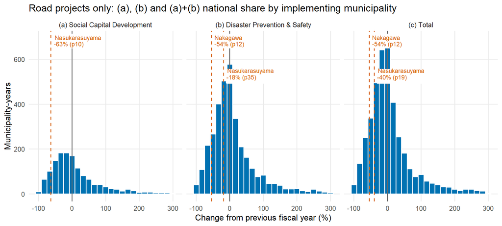

Figure 4: Year-on-year change in road-project national share (%, FY2022-23 to FY2025-26 pooled), by implementing municipality; changes above +300% omitted ((a) 65, (b) 136, (a)+(b) 146 municipality-years). Dashed orange: Nasukarasuyama, Nakagawa in FY2026, with their percentile among all pooled changes.  
Source: MLIT Road Bureau, various years (FY2022-FY2026) (社会資本整備総合交付金の配分（道路分）, 別紙; 想定国費)

```r
lab <- two[, .(grant_lab, chg, lab = sprintf("%s\n%.0f%% (p%.0f)",
               c(那須烏山市 = "Nasukarasuyama", 那珂川町 = "Nakagawa")[entity], chg, pctile))]
lab[, vj := 1.2 + 2.4 * (seq_len(.N) - 1), by = grant_lab]   # stack labels within a panel
p_hm <- ggplot(pool[chg <= 300], aes(chg)) +
  labs(title = "Road projects only: (a), (b) and (a)+(b) national share by implementing municipality") +
  geom_histogram(bins = 25, fill = "#0072B2", colour = "white") +
  geom_vline(xintercept = 0, colour = "grey40") +
  geom_vline(data = lab, aes(xintercept = chg), colour = "#D55E00", linetype = "dashed") +
  geom_label(data = lab, aes(x = chg, y = Inf, label = lab, vjust = vj), colour = "#D55E00",
             fill = "white", label.size = 0, hjust = -0.05, size = 3, lineheight = 0.9) +
  facet_wrap(~grant_lab) +
  labs(x = "Change from previous fiscal year (%)", y = "Municipality-years") +
  theme_minimal(base_size = 12) +
  theme(panel.grid.minor = element_blank())
ggsave("data/mlit_hist_muni.png", p_hm, width = 10, height = 4.5, dpi = 200, bg = "white")
p_hm
pool[, .(n = .N, above300 = sum(chg > 300)), by = grant_lab]
```

**Code (Fig: municipal road map, FY2025→26)**

```r
# Municipal boundaries: MLIT N03 (2021-01-01), simplified by SmartNews SMRI (japan-topography)
dir.create("data/n03", showWarnings = FALSE)
nf <- sprintf("data/n03/N03-21_%02d_210101.json", 1:47)
for (i in 1:47) if (!file.exists(nf[i]))
  download.file(sprintf(paste0("https://raw.githubusercontent.com/smartnews-smri/japan-topography/",
                               "main/data/municipality/geojson/s0010/N03-21_%02d_210101.json"), i),
                nf[i], mode = "wb")
mm <- do.call(rbind, lapply(nf, sf::st_read, quiet = TRUE))
mm$code <- as.integer(substr(mm$N03_007, 1, 2))
# Designated cities appear as wards in N03 but as the city in the PDFs
ward <- !is.na(mm$N03_003) & grepl("市$", mm$N03_003) & grepl("区$", mm$N03_004)
mm$entity <- ifelse(ward, mm$N03_003, mm$N03_004)
norm <- function(x) gsub("ヶ", "ケ", x)
last <- mu[fy == 2026 & grant == "c", .(code, key = norm(entity), chg)]
mm$key <- norm(mm$entity)
mp <- merge(mm, last, by = c("code", "key"), all.x = TRUE)
cat("annex municipalities not matched to a boundary:",
    nrow(last[!mm, on = .(code, key)]), "of", nrow(last), "\n")
```

```
annex municipalities not matched to a boundary: 0 of 1459
```

**Code (Fig: municipal road map, FY2025→26)**

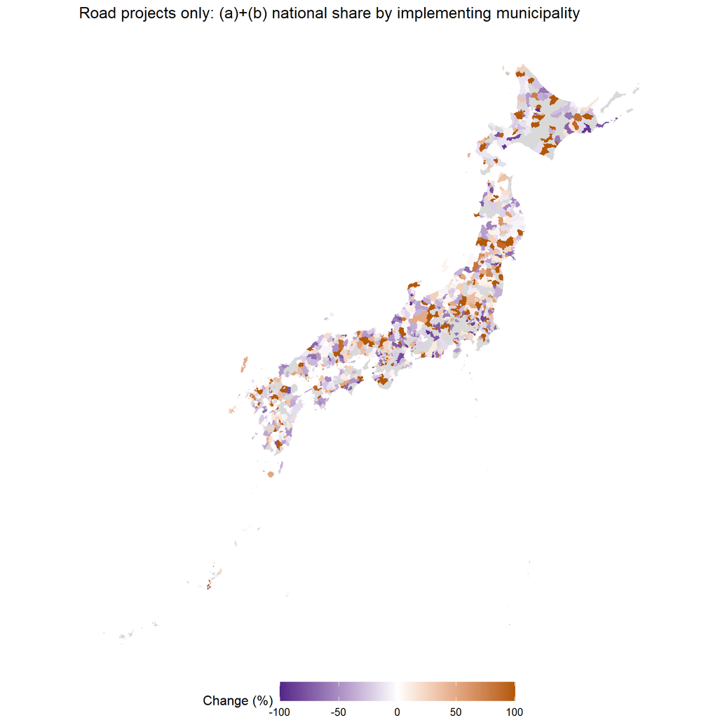

Figure 5: Change in road-project national share (a)+(b) (%, FY2025-26), by implementing municipality. Purple = decrease, orange = increase; colours capped at ±100%; grey = no listed municipal project in one of the two years.  
Source: MLIT Road Bureau, FY2025-FY2026 (社会資本整備総合交付金の配分（道路分）, 別紙; 想定国費). Boundaries: MLIT N03 (2021-01-01), simplified by SmartNews SMRI (japan-topography)

```r
sc <- scale_fill_gradient2(low = "#542788", mid = "white", high = "#B35806", midpoint = 0,
                           limits = c(-100, 100), oob = scales::squish, na.value = "grey85",
                           name = "Change (%)")
p_mm <- ggplot(mp) + geom_sf(aes(fill = chg), colour = NA) + sc +
  labs(title = "Road projects only: (a)+(b) national share by implementing municipality") +
  coord_sf(xlim = c(123, 146), ylim = c(24, 46)) +
  theme_void(base_size = 12) + theme(legend.position = "bottom", legend.key.width = unit(1.5, "cm"))
ggsave("data/mlit_map_muni_fy2026.png", p_mm, width = 9, height = 9, dpi = 200, bg = "white")
p_mm
```

**Code (Fig: Kanto map, cuts ≥ Nasukarasuyama labelled)**

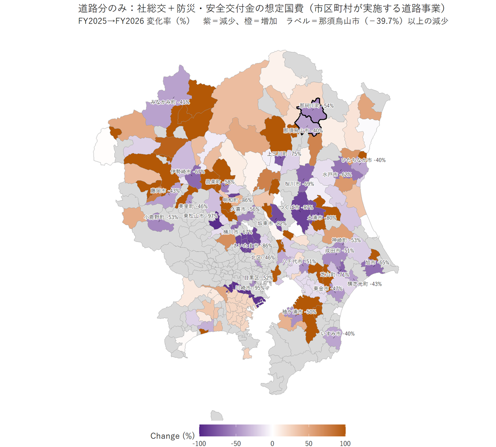

Figure 6: Kanto: change in road-project national share (a)+(b) (%, FY2025-26), by implementing municipality. Labelled: every municipality whose cut is at least Nasukarasuyama’s (−39.7%); thick outline: 那須烏山市, 那珂川町; grey = no listed municipal project in FY2025 or FY2026; Tokyo’s islands omitted.  
Source: MLIT Road Bureau, FY2025-FY2026 (社会資本整備総合交付金の配分（道路分）, 別紙; 想定国費). Boundaries: MLIT N03 (2021-01-01), simplified by SmartNews SMRI (japan-topography)

```r
# Japanese font for kanji labels (Windows); falls back to the default family elsewhere
jpf <- if (.Platform$OS.type == "windows") { windowsFonts(JP = windowsFont("Yu Gothic")); "JP" } else ""
kanto <- 8:14                                              # 茨城 栃木 群馬 埼玉 千葉 東京 神奈川
kt <- mp[mp$code %in% kanto, ]
cut0 <- mu[code == 9 & entity == "那須烏山市" & fy == 2026 & grant == "c", chg]   # -39.7
big <- mu[code %in% kanto & fy == 2026 & grant == "c" & !is.na(chg) & chg <= cut0]
# One label point per municipality (designated cities are split into wards in N03)
kt$id <- paste(kt$code, kt$entity)
lb <- kt[kt$id %in% big[, paste(code, entity)], ]
lb <- do.call(rbind, lapply(split(lb, lb$id), function(x)
  sf::st_sf(entity = x$entity[1], chg = x$chg[1],
            geometry = sf::st_point_on_surface(sf::st_union(x$geometry)))))
xy <- sf::st_coordinates(lb)
lb$x <- xy[, 1]; lb$y <- xy[, 2]
hl <- kt[kt$code == 9 & kt$entity %in% c("那須烏山市", "那珂川町"), ]
p_kt <- ggplot(kt) + geom_sf(aes(fill = chg), colour = "grey60", linewidth = 0.05) + sc +
  labs(title = "道路分のみ：社総交＋防災・安全交付金の想定国費（市区町村が実施する道路事業）",
       subtitle = "FY2025→FY2026 変化率（%）　紫＝減少、橙＝増加　ラベル＝那須烏山市（−39.7%）以上の減少") +
  geom_sf(data = hl, fill = NA, colour = "black", linewidth = 0.8) +
  ggrepel::geom_text_repel(data = lb, aes(x, y, label = sprintf("%s %.0f%%", entity, chg)),
                           family = jpf, size = 2.6, min.segment.length = 0, segment.size = 0.2,
                           max.overlaps = Inf, box.padding = 0.25, seed = 1,
                           bg.color = "white", bg.r = 0.15) +
  coord_sf(xlim = c(138.4, 140.9), ylim = c(34.85, 37.2)) +
  theme_void(base_size = 12) + theme(legend.position = "bottom", legend.key.width = unit(1.5, "cm"),
                                     text = element_text(family = jpf))
ggsave("data/mlit_map_kanto_fy2026.png", p_kt, width = 10, height = 9, dpi = 200, bg = "white")
p_kt
```

**Code (Table: Kanto municipalities with cuts ≥ 39.7%)**

```r
kc <- big[order(chg), .(`都県` = jis[code], `自治体` = entity,
                        FY2025 = format(prev, big.mark = ","), FY2026 = format(kyen, big.mark = ","),
                        `変化%` = sprintf("%.1f", chg))]
kc_n <- mu[code %in% kanto & fy == 2026 & grant == "c",
           .(both_years = sum(!is.na(chg)), dropped_to_0 = sum(prev > 0 & kyen == 0))]
ttj(kc, 1:2, 3:5)
```

Table 2: Kanto municipalities with FY2026 cuts at least as large as Nasukarasuyama’s (−39.7%), national share in 1,000 yen, (c) 合計; counts below the table.

| 都県 | 自治体 | FY2025 | FY2026 | 変化% |
| --- | --- | --- | --- | --- |
| 埼玉 | 東松山市 | 401,047 | 11,000 | -97.3 |
| 神奈川 | 川崎市 | 336,081 | 16,000 | -95.2 |
| 茨城 | つくば市 | 439,872 | 58,428 | -86.7 |
| 埼玉 | さいたま市 | 1,959,907 | 276,500 | -85.9 |
| 群馬 | 明和町 | 221,500 | 32,000 | -85.6 |
| 茨城 | 坂東市 | 170,052 | 30,800 | -81.9 |
| 茨城 | 土浦市 | 209,090 | 41,275 | -80.3 |
| 栃木 | 上三川町 | 352,528 | 86,394 | -75.5 |
| 千葉 | 芝山町 | 173,600 | 51,100 | -70.6 |
| 茨城 | 桜川市 | 70,013 | 21,862 | -68.8 |
| 群馬 | 伊勢崎市 | 529,771 | 172,450 | -67.4 |
| 埼玉 | 桶川市 | 50,780 | 17,011 | -66.5 |
| 千葉 | 旭市 | 50,688 | 17,638 | -65.2 |
| 茨城 | 水戸市 | 1,048,233 | 393,939 | -62.4 |
| 群馬 | 邑楽町 | 29,623 | 12,500 | -57.8 |
| 埼玉 | 久喜市 | 58,765 | 26,000 | -55.8 |
| 栃木 | 那珂川町 | 49,342 | 22,624 | -54.1 |
| 埼玉 | 小鹿野町 | 38,600 | 18,000 | -53.4 |
| 千葉 | 神崎町 | 58,323 | 27,546 | -52.8 |
| 東京 | 目黒区 | 969,053 | 464,400 | -52.1 |
| 千葉 | 成田市 | 113,864 | 55,704 | -51.1 |
| 千葉 | 八千代市 | 101,329 | 49,575 | -51.1 |
| 千葉 | 袖ケ浦市 | 100,320 | 50,473 | -49.7 |
| 千葉 | 東金市 | 398,408 | 210,490 | -47.2 |
| 東京 | 北区 | 39,872 | 21,450 | -46.2 |
| 埼玉 | 美里町 | 30,199 | 16,350 | -45.9 |
| 千葉 | 横芝光町 | 36,859 | 21,109 | -42.7 |
| 群馬 | 藤岡市 | 432,442 | 248,050 | -42.6 |
| 群馬 | みなかみ町 | 172,250 | 101,000 | -41.4 |
| 千葉 | いすみ市 | 28,600 | 17,160 | -40.0 |
| 茨城 | ひたちなか市 | 164,580 | 99,000 | -39.8 |
| 栃木 | 那須烏山市 | 136,788 | 82,508 | -39.7 |

- Kanto, (c) 合計, FY2026: 143 municipalities with listed road projects in both years, of which 32 were cut by 39.7% or more; 33 more had all listed projects disappear (FY2026 = 0).

Saved files in `data/`:

- `mlit_grants_pref.qs2`, `mlit_grants_pref.csv`: prefecture x year x grant panel with % change
- `mlit_road_muni.qs2`, `mlit_road_muni.csv`: municipality x year x grant road-project panel with % change
- `mlit_hist_change.png`, `mlit_map_change_fy2026.png`: prefecture histogram and map
- `mlit_hist_muni.png`, `mlit_map_muni_fy2026.png`, `mlit_map_kanto_fy2026.png`: municipal histogram and maps
- Inputs: `R4-R8_shakai.pdf`, `road/` (235 PDFs), `gadm41_JPN_1.json.zip`, `n03/` (47 GeoJSON)